# Distributions for GLMMs

Response types, links and overdispersion

O Rodriguez de Rivera Ortega, PhD

University of Exeter

# Session context

## Why start with distributions?

GLMMs combine two ideas:

- **GLMs:** choose a response distribution and link function appropriate for the data;
- **mixed models:** account for grouping, repeated measurements or clustering.

Before fitting mixed models, we need to know what kind of response we are modelling.

## Learning outcomes

By the end of this section, students should be able to:

- distinguish continuous, binary, binomial and count responses;
- identify common distributions used in GLMs and GLMMs;
- explain the role of the link function;
- recognise overdispersion in count or binomial data;
- connect response type to an R model family.

# Setup

## Packages

```r
install.packages(c("tidyverse", "patchwork"))
```

```r
library(tidyverse)
library(patchwork)

theme_set(theme_minimal(base_size = 12))
```

# Response types

## What kind of response do we have?

| Response | Examples | Common distribution | Link |
| --- | --- | --- | --- |
| Continuous, symmetric | height, biomass, temperature | Normal | identity |
| Continuous, positive and skewed | concentration, waiting time | Gamma / lognormal | log |
| Binary 0/1 | presence/absence, survived/died | Bernoulli / Binomial | logit |
| Proportion from counts | successes out of trials | Binomial | logit |
| Counts | abundance, infections, visits | Poisson / negative binomial | log |

GLMMs add random effects to these models when the observations are grouped.

## A simple decision tree

1. Is the response continuous?
   - approximately symmetric: consider Gaussian;
   - positive and skewed: consider Gamma or lognormal.
2. Is the response binary or a proportion from known trials?
   - consider Binomial.
3. Is the response a count?
   - start with Poisson;
   - check overdispersion;
   - consider negative binomial if variance is much larger than the mean.

# Continuous distributions

## Normal distribution

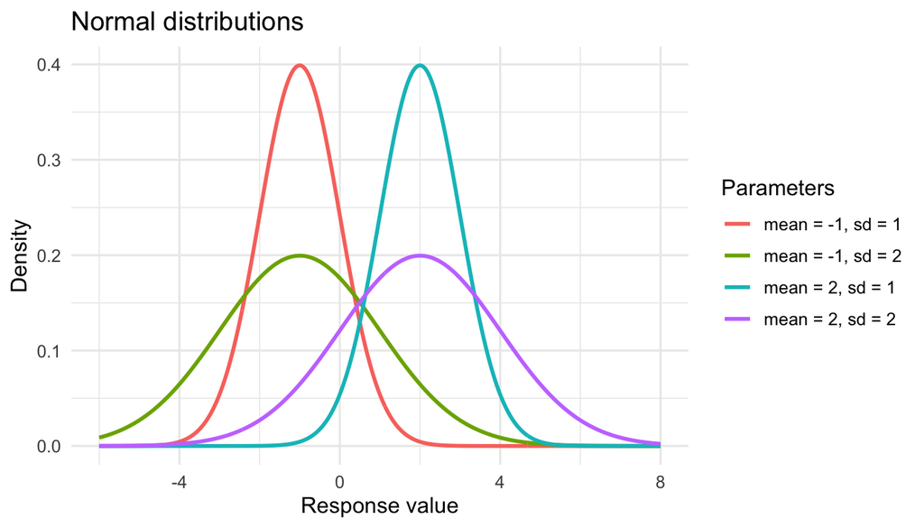

```r
normal_df <- crossing(
  x = seq(-6, 8, length.out = 500),
  mean = c(-1, 2),
  sd = c(1, 2)
) %>%
  mutate(
    density = dnorm(x, mean = mean, sd = sd),
    scenario = paste0("mean = ", mean, ", sd = ", sd)
  )

ggplot(normal_df, aes(x = x, y = density, colour = scenario)) +
  geom_line(linewidth = 1) +
  labs(
    title = "Normal distributions",
    x = "Response value",
    y = "Density",
    colour = "Parameters"
  )
```

## When is Gaussian reasonable?

A Gaussian model is often reasonable when:

- the response can take values above and below the mean;
- residuals are approximately symmetric;
- there is no strong lower or upper bound close to the data;
- the mean-variance relationship is weak.

In mixed models, this is the linear mixed model case:

```r
lme4::lmer(response ~ fixed_effects + (1 | group), data = my_data)
```

# Binary and binomial responses

## Binomial distribution

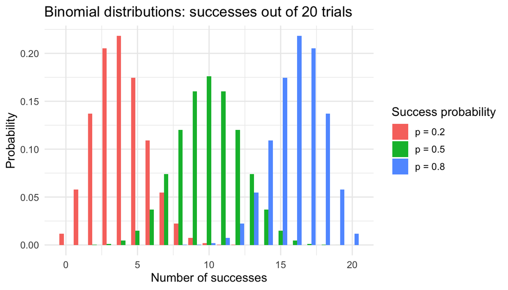

```r
binomial_df <- crossing(
  successes = 0:20,
  probability = c(0.2, 0.5, 0.8)
) %>%
  mutate(
    probability_mass = dbinom(successes, size = 20, prob = probability),
    scenario = paste0("p = ", probability)
  )

ggplot(binomial_df, aes(x = successes, y = probability_mass, fill = scenario)) +
  geom_col(position = "dodge") +
  labs(
    title = "Binomial distributions: successes out of 20 trials",
    x = "Number of successes",
    y = "Probability",
    fill = "Success probability"
  )
```

## Binary versus grouped binomial data

Binary data:

```r
glmer(presence ~ habitat + (1 | site),
      family = binomial,
      data = my_data)
```

Grouped binomial data:

```r
glmer(cbind(successes, failures) ~ treatment + (1 | group),
      family = binomial,
      data = my_data)
```

Grouped binomial models are useful when each row contains several trials.

# Count responses

## Poisson distribution

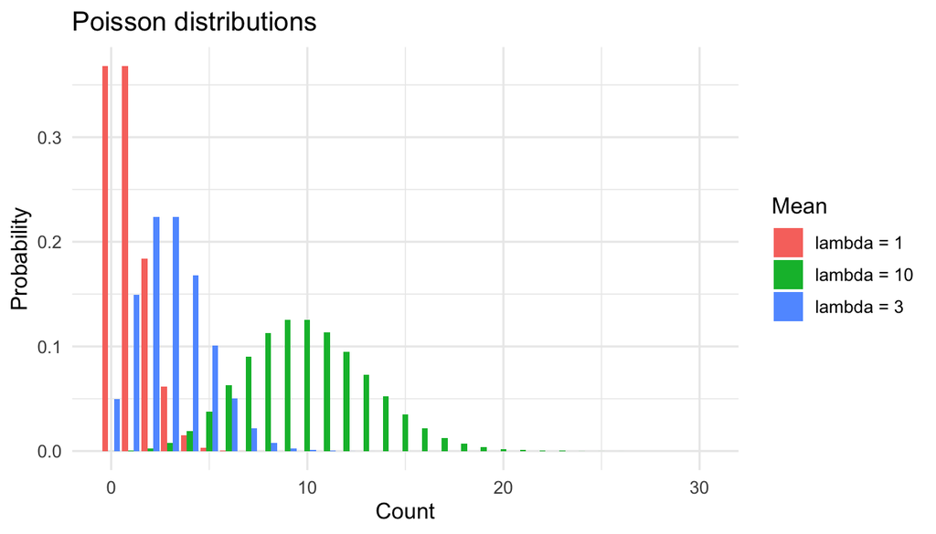

```r
poisson_df <- crossing(
  count = 0:30,
  lambda = c(1, 3, 10)
) %>%
  mutate(
    probability = dpois(count, lambda = lambda),
    scenario = paste0("lambda = ", lambda)
  )

ggplot(poisson_df, aes(x = count, y = probability, fill = scenario)) +
  geom_col(position = "dodge") +
  labs(
    title = "Poisson distributions",
    x = "Count",
    y = "Probability",
    fill = "Mean"
  )
```

## Poisson assumption

For a Poisson model:

$$E(Y_i) = \mu_i, \qquad Var(Y_i) =
\mu_i.$$

This is convenient, but often too restrictive. Ecological and environmental count data frequently have **overdispersion**:

$$Var(Y_i) > E(Y_i).$$

Possible reasons include:

- missing covariates;
- unmodelled grouping;
- heterogeneity among individuals/sites;
- excess zeros;
- the wrong distribution.

## Negative binomial distribution

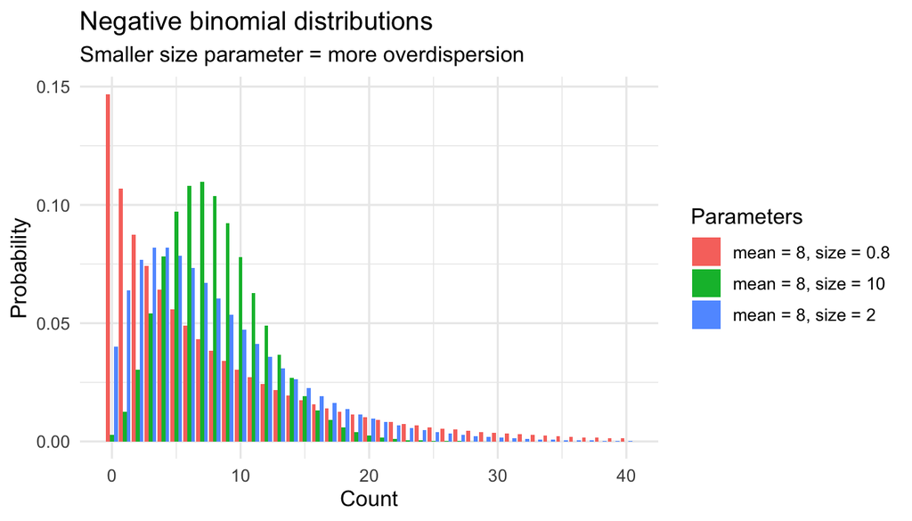

```r
nb_df <- crossing(
  count = 0:40,
  size = c(0.8, 2, 10)
) %>%
  mutate(
    mean = 8,
    probability = dnbinom(count, mu = mean, size = size),
    scenario = paste0("mean = 8, size = ", size)
  )

ggplot(nb_df, aes(x = count, y = probability, fill = scenario)) +
  geom_col(position = "dodge") +
  labs(
    title = "Negative binomial distributions",
    subtitle = "Smaller size parameter = more overdispersion",
    x = "Count",
    y = "Probability",
    fill = "Parameters"
  )
```

## Poisson versus negative binomial simulation

```r
set.seed(123)

sim_counts <- tibble(
  poisson = rpois(5000, lambda = 5),
  negative_binomial = rnbinom(5000, mu = 5, size = 1)
) %>%
  pivot_longer(everything(), names_to = "model", values_to = "count")

sim_counts %>%
  group_by(model) %>%
  summarise(
    mean = mean(count),
    variance = var(count),
    .groups = "drop"
  )
```

```
## # A tibble: 2 × 3
##   model              mean variance
##   <chr>             <dbl>    <dbl>
## 1 negative_binomial  4.88    28.7
## 2 poisson            4.97     4.93
```

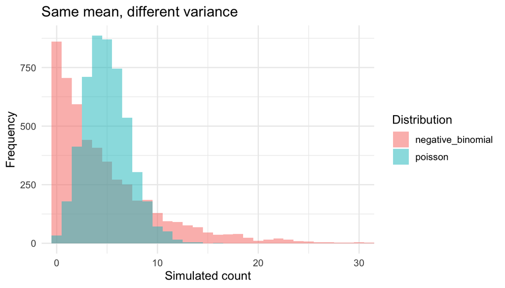

```r
ggplot(sim_counts, aes(x = count, fill = model)) +
  geom_histogram(binwidth = 1, position = "identity", alpha = 0.5) +
  coord_cartesian(xlim = c(0, 30)) +
  labs(
    title = "Same mean, different variance",
    x = "Simulated count",
    y = "Frequency",
    fill = "Distribution"
  )
```

# Link functions

## Why links matter

A link function connects the expected response to the linear predictor:

$$g(\mu_i) = \eta_i = \beta_0 + \beta_1
x_i.$$

The link keeps predictions in the correct range:

- logit link keeps probabilities between 0 and 1;
- log link keeps counts positive;
- identity link leaves the response on its original scale.

## Logit link for probabilities

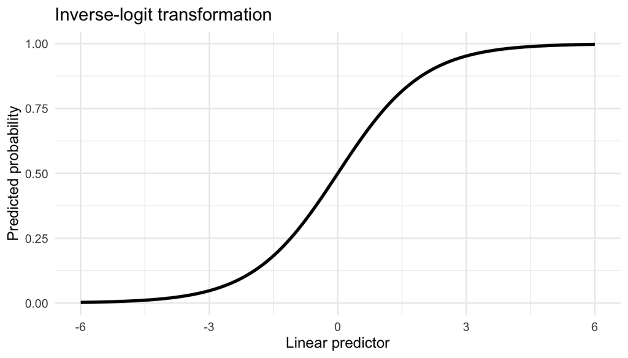

```r
eta_df <- tibble(eta = seq(-6, 6, length.out = 400)) %>%
  mutate(probability = plogis(eta))

ggplot(eta_df, aes(x = eta, y = probability)) +
  geom_line(linewidth = 1.2) +
  labs(
    title = "Inverse-logit transformation",
    x = "Linear predictor",
    y = "Predicted probability"
  )
```

## Log link for counts

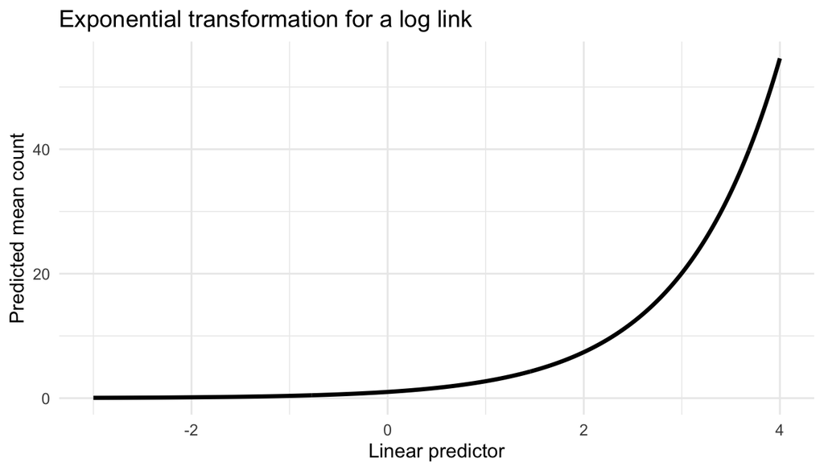

```r
log_df <- tibble(eta = seq(-3, 4, length.out = 400)) %>%
  mutate(mean_count = exp(eta))

ggplot(log_df, aes(x = eta, y = mean_count)) +
  geom_line(linewidth = 1.2) +
  labs(
    title = "Exponential transformation for a log link",
    x = "Linear predictor",
    y = "Predicted mean count"
  )
```

# Practical checkpoints

## Model family cheat sheet

```r
# Continuous response, grouped data
lmer(y ~ x + (1 | group), data = my_data)

# Binary or grouped binomial response, grouped data
glmer(y ~ x + (1 | group), family = binomial, data = my_data)
glmer(cbind(successes, failures) ~ x + (1 | group), family = binomial, data = my_data)

# Count response, grouped data
glmer(count ~ x + (1 | group), family = poisson, data = my_data)

# Overdispersed counts
lme4::glmer.nb(count ~ x + (1 | group), data = my_data)
# or, as an extension:
glmmTMB::glmmTMB(count ~ x + (1 | group), family = nbinom2, data = my_data)
```

## Short exercise

For each example, choose a likely model family and a possible random effect.

1. Number of seedlings per quadrat, sampled in several forests.
2. Whether an animal was detected or not at repeated visits to camera traps.
3. Number of infected plants out of 30 plants sampled in each field.
4. Body mass of animals measured repeatedly through time.
5. Number of ticks on chicks from different broods.

### Comments

1. **Number of seedlings per quadrat, sampled in several forests**

This is a count response, so a Poisson GLMM is a natural starting point:

```r
lme4::glmer(
  seedlings ~ habitat + (1 | forest),
  family = poisson(link = "log"),
  data = seedling_data
)
```

If the variance is much larger than the mean, a negative-binomial model may be more appropriate:

```r
lme4::glmer.nb(
  seedlings ~ habitat + (1 | forest),
  data = seedling_data
)
```

2. **Whether an animal was detected or not at repeated visits to camera traps**

This is a binary response: detected or not detected. A binomial GLMM with a logit link is appropriate. The repeated structure could be handled using a random effect for camera trap or site.

```r
lme4::glmer(
  detected ~ habitat + time_of_day + (1 | camera_trap),
  family = binomial(link = "logit"),
  data = detection_data
)
```

3. **Number of infected plants out of 30 plants sampled in each field**

This is grouped binomial data: the response is the number of successes out of a fixed number of trials. The model should use `cbind(successes, failures)`.

```r
lme4::glmer(
  cbind(infected, 30 - infected) ~ treatment + (1 | field),
  family = binomial(link = "logit"),
  data = infection_data
)
```

4. **Body mass of animals measured repeatedly through time**

Body mass is continuous, so a Gaussian mixed model is a reasonable starting point. Because the same animals are measured repeatedly, animal identity should be included as a random effect.

```r
lme4::lmer(
  body_mass ~ time + treatment + (1 | animal_id),
  data = body_mass_data
)
```

If individuals differ in their change through time, we could include a random slope:

```r
lme4::lmer(
  body_mass ~ time + treatment + (1 + time | animal_id),
  data = body_mass_data
)
```

5. **Number of ticks on chicks from different broods**

This is a count response, so a Poisson GLMM is a natural starting point. Chicks from the same brood are likely to be more similar to each other, so brood can be included as a random effect.

```r
lme4::glmer(
  ticks ~ chick_size + treatment + (1 | brood),
  family = poisson(link = "log"),
  data = tick_data
)
```

If tick counts are overdispersed, a negative-binomial model is often better:

```r
lme4::glmer.nb(
  ticks ~ chick_size + treatment + (1 | brood),
  data = tick_data
)
```

### Key message

The distribution should match the response type. Random effects are used when observations are grouped, clustered or repeatedly measured. For count data, always check overdispersion before relying on a Poisson model.

## Take-home message

Before fitting a GLMM, decide:

1. What is the response type?
2. What distribution is appropriate?
3. What link function keeps predictions in the correct range?
4. What grouping structure makes observations non-independent?